# Real_estate_mezban

```python
#Taking Hamilton and Manhattan cities data
columns = ['second_mortgage','home_equity','debt','bad_debt']
city_hamilton = df_train.loc[df_train['city']=="Hamilton"]
city_manhattan = df_train.loc[df_train['city'] == "Manhattan"]
df_box_city = pd.concat([city_hamilton,city_manhattan])
df_box_city.head()
```

| UID | COUNTYID | STATEID | state | state_ab | city | place | type | primary | zip_code | area_code | ... | female_age_stdev | female_age_sample_weight | female_age_samples | pct_own | married | married_snp | separated | divorced | bad_dept | bins |
| --- | --- | --- | --- | --- | --- | --- | --- | --- | --- | --- | --- | --- | --- | --- | --- | --- | --- | --- | --- | --- | --- |
| 270981 | 17 | 39 | Ohio | OH | Hamilton | Hamilton City | Village | tract | 45011 | 513 | ... | 20.69511 | 582.77189 | 2080.0 | 0.29017 | 0.32129 | 0.13063 | 0.05837 | 0.08616 | 0.12159 | 50% - 100% |
| 259428 | 81 | 30 | Montana | MT | Hamilton | Pinesdale | CDP | tract | 59840 | 406 | ... | 24.28726 | 374.79254 | 1494.0 | 0.68075 | 0.58489 | 0.03042 | 0.00981 | 0.14524 | 0.05463 | less than 50% |
| 259431 | 81 | 30 | Montana | MT | Hamilton | Charlos Heights | CDP | tract | 59840 | 406 | ... | 23.72555 | 740.81529 | 3134.0 | 0.60721 | 0.49758 | 0.02791 | 0.01600 | 0.19762 | 0.07629 | less than 50% |
| 270985 | 17 | 39 | Ohio | OH | Hamilton | New Miami | Village | tract | 45013 | 513 | ... | 24.42104 | 741.11750 | 3177.0 | 0.60436 | 0.57778 | 0.05652 | 0.02995 | 0.20386 | 0.23273 | 50% - 100% |
| 240011 | 145 | 13 | Georgia | GA | Hamilton | Hamilton City | City | tract | 31811 | 706 | ... | 22.60194 | 633.64056 | 2686.0 | 0.72375 | 0.59681 | 0.02060 | 0.01287 | 0.12152 | 0.08940 | less than 50% |

5 rows × 79 columns

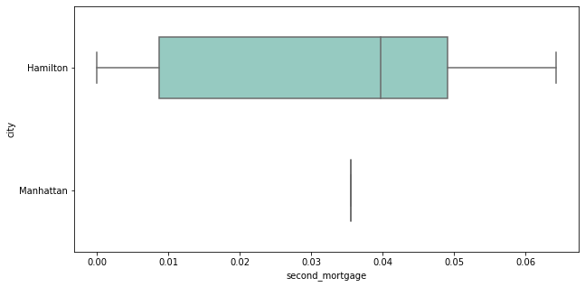

```python
plt.figure(figsize=(10,5))
sns.boxplot(data=df_box_city,x='second_mortgage', y='city',width=0.5,palette="Set3")
plt.show()
```

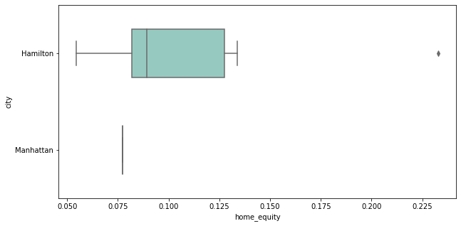

```python
plt.figure(figsize=(10,5))
sns.boxplot(data=df_box_city,x='home_equity', y='city',width=0.5,palette="Set3")
plt.show()
```

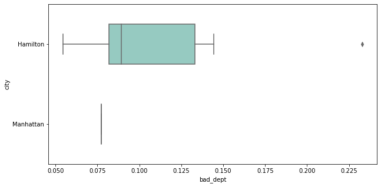

```python
plt.figure(figsize=(10,5))
sns.boxplot(data=df_box_city,x='bad_dept', y='city',width=0.5,palette="Set3")
plt.show()
```

### Creating a collated income distribution chart for family income, house hold income, and remaining income

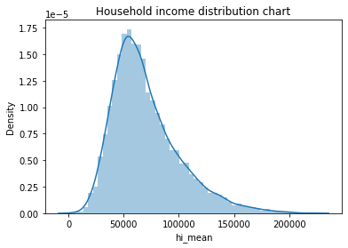

```python
sns.distplot(df_train['hi_mean'])
plt.title('Household income distribution chart')
plt.show()
```

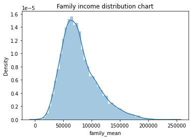

```python
sns.distplot(df_train['family_mean'])
plt.title('Family income distribution chart')
plt.show()
```

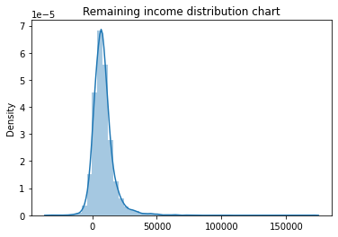

```python
sns.distplot(df_train['family_mean']-df_train['hi_mean'])
plt.title('Remaining income distribution chart')
plt.show()
```

### Exploratory Data Analysis (EDA):

#### Use pop and ALand variables to create a new field called population density

```python
df_train['pop_density'] = df_train['pop']/df_train['ALand']
df_test['pop_density'] = df_test['pop']/df_test['ALand']
```

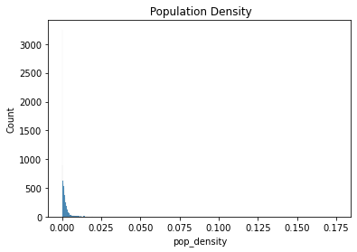

```python
sns.histplot(df_train['pop_density'])
plt.title(" Population Density")
plt.show()
```

#### Use male_age_median, female_age_median, male_pop, and female_pop to create a new field called median age

```python
df_train['age_median'] = (df_train['male_age_median']+df_train['female_age_median'])/2
df_test['age_median'] = (df_test['male_age_median']+df_test['female_age_median'])/2
```

```python
df_train[['male_age_median','female_age_median','male_pop','female_pop','age_median']].head()
```

| UID | male_age_median | female_age_median | male_pop | female_pop | age_median |
| --- | --- | --- | --- | --- | --- |
| 255504 | 27.83333 | 33.75000 | 1479 | 1938 | 30.791665 |
| 252676 | 46.08333 | 46.66667 | 1846 | 1950 | 46.375000 |
| 276314 | 41.91667 | 44.50000 | 2065 | 1879 | 43.208335 |
| 248614 | 43.00000 | 48.00000 | 1427 | 1081 | 45.500000 |
| 286865 | 43.75000 | 42.66667 | 3274 | 2956 | 43.208335 |

#### c) Visualize the findings using appropriate chart type

[figure not shown]

```python
sns.histplot(df_train['age_median'])
plt.title(" Population density")
plt.show()
```

[figure not shown]

```python
sns.boxplot(df_train['age_median'])
plt.title(" Population density")
plt.show()
```

#### Create bins for population into a new variable by selecting appropriate class interval so that the number of categories don’t exceed 5 for the ease of analysis.

```python
df_train['pop'].describe()
```

```
count    11709.000000
mean      4367.205995
std       2121.779736
min          0.000000
25%       2937.000000
50%       4119.000000
75%       5474.000000
max      39454.000000
Name: pop, dtype: float64
```

```python
df_train['pop_bins'] = pd.cut(df_train['pop'], bins=5, labels=['very low', 'low', 'medium', 'high', 'very_high'])
```

```python
df_train['pop_bins'].head()
```

```
UID
255504    very low
252676    very low
276314    very low
248614    very low
286865    very low
Name: pop_bins, dtype: category
Categories (5, object): ['very low' < 'low' < 'medium' < 'high' < 'very_high']
```

#### a) Analyze the married, separated, and divorced population for these population brackets

```python
df_train.groupby(by='pop_bins')[['married','separated','divorced']].count()
```

| pop_bins | married | separated | divorced |
| --- | --- | --- | --- |
| very low | 11132 | 11132 | 11132 |
| low | 553 | 553 | 553 |
| medium | 22 | 22 | 22 |
| high | 1 | 1 | 1 |
| very_high | 1 | 1 | 1 |

```python
df_train.groupby(by='pop_bins')[['married','separated','divorced']].agg(["mean", "median"])
```

| pop_bins | married mean | married median | separated mean | separated median | divorced mean | divorced median |
| --- | --- | --- | --- | --- | --- | --- |
| very low | 0.503005 | 0.522655 | 0.019493 | 0.01404 | 0.100010 | 0.095200 |
| low | 0.556673 | 0.574380 | 0.016519 | 0.01169 | 0.083023 | 0.078070 |
| medium | 0.607044 | 0.603325 | 0.013605 | 0.00786 | 0.075038 | 0.072905 |
| high | 0.403120 | 0.403120 | 0.046180 | 0.04618 | 0.086930 | 0.086930 |
| very_high | 0.335660 | 0.335660 | 0.002500 | 0.00250 | 0.010320 | 0.010320 |

#### b) Visualize using appropriate chart type

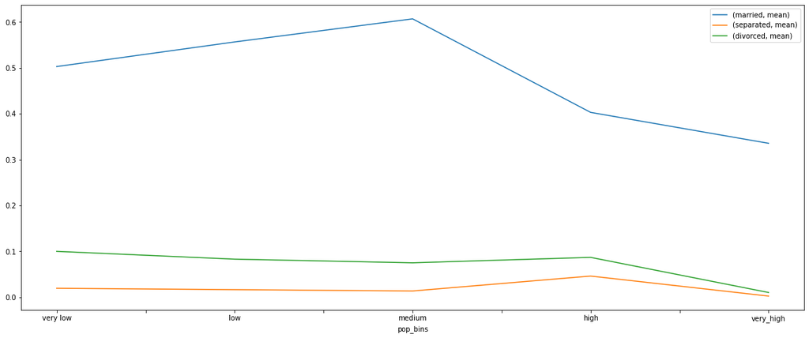

```python
plt.figure(figsize=(10,5))
pop_bin_married=df_train.groupby(by='pop_bins')[['married','separated','divorced']].agg(["mean"])
pop_bin_married.plot(figsize=(20,8))
plt.legend(loc='best')
plt.show()
```

#### 3. Please detail your observations for rent as a percentage of income at an overall level, and for different states.

```python
df_train.columns
```

```
Index(['COUNTYID', 'STATEID', 'state', 'state_ab', 'city', 'place', 'type',
       'primary', 'zip_code', 'area_code', 'lat', 'lng', 'ALand', 'AWater',
       'pop', 'male_pop', 'female_pop', 'rent_mean', 'rent_median',
       'rent_stdev', 'rent_sample_weight', 'rent_samples', 'rent_gt_10',
       'rent_gt_15', 'rent_gt_20', 'rent_gt_25', 'rent_gt_30', 'rent_gt_35',
       'rent_gt_40', 'rent_gt_50', 'universe_samples', 'used_samples',
       'hi_mean', 'hi_median', 'hi_stdev', 'hi_sample_weight', 'hi_samples',
       'family_mean', 'family_median', 'family_stdev', 'family_sample_weight',
       'family_samples', 'hc_mortgage_mean', 'hc_mortgage_median',
       'hc_mortgage_stdev', 'hc_mortgage_sample_weight', 'hc_mortgage_samples',
       'hc_mean', 'hc_median', 'hc_stdev', 'hc_samples', 'hc_sample_weight',
       'home_equity_second_mortgage', 'second_mortgage', 'home_equity', 'debt',
       'second_mortgage_cdf', 'home_equity_cdf', 'debt_cdf', 'hs_degree',
       'hs_degree_male', 'hs_degree_female', 'male_age_mean',
       'male_age_median', 'male_age_stdev', 'male_age_sample_weight',
       'male_age_samples', 'female_age_mean', 'female_age_median',
       'female_age_stdev', 'female_age_sample_weight', 'female_age_samples',
       'pct_own', 'married', 'married_snp', 'separated', 'divorced',
       'bad_dept', 'bins', 'pop_density', 'age_median', 'pop_bins'],
      dtype='object')
```

```python
rent_state_mean = df_train.groupby(by = 'state')['rent_mean'].agg(["mean"])
```

```python
rent_state_mean.head()
```

| state | mean |
| --- | --- |
| Alabama | 750.652199 |
| Alaska | 1200.918640 |
| Arizona | 1058.562230 |
| Arkansas | 713.389759 |
| California | 1448.716251 |

```python
income_state_mean = df_train.groupby(by= 'state')['family_mean'].agg(["mean"])
```

```python
income_state_mean.head()
```

| state | mean |
| --- | --- |
| Alabama | 61863.280021 |
| Alaska | 91347.618550 |
| Arizona | 72341.096212 |
| Arkansas | 63926.596192 |
| California | 87176.404965 |

```python
rent_perc_of_income=rent_state_mean['mean']/income_state_mean['mean']
rent_perc_of_income.head(10)
```

```
state
Alabama                 0.012134
Alaska                  0.013147
Arizona                 0.014633
Arkansas                0.011160
California              0.016618
Colorado                0.013818
Connecticut             0.013031
Delaware                0.013433
District of Columbia    0.014385
Florida                 0.015731
Name: mean, dtype: float64
```

```python
#overall level rent as a percentage of income
sum(df_train['rent_mean'])/sum(df_train['family_mean'])
```

```
0.0134001539513542
```

#### 4. Perform correlation analysis for all the relevant variables by creating a heatmap. Describe your findings.

```python
cor=df_train[['COUNTYID','STATEID','zip_code','type','pop', 'family_mean',
         'second_mortgage', 'home_equity', 'debt','hs_degree',
           'age_median','pct_own', 'married','separated', 'divorced']].corr()
```

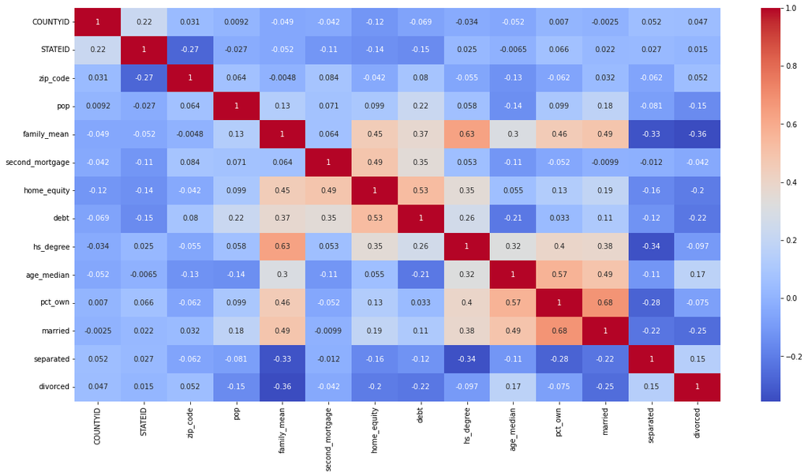

```python
plt.figure(figsize=(20,10))
sns.heatmap(cor,annot=True,cmap='coolwarm')
plt.show()
```